# Understanding the data set

> ** Understanding the data set**: This data set contains 113,937 loans with 81 variables on each loan, including loan amount, borrower rate (or interest rate), current loan status, borrower income, borrower employment status, borrower credit history, and the latest payment information.

[This](https://docs.google.com/spreadsheets/d/1gDyi_L4UvIrLTEC6Wri5nbaMmkGmLQBk-Yx3z0XDEtI/edit?usp=sharing) is the Variables dictionary which contains helpful info about each summary. some interesting variables that we could look at: - IncomeRange - BorrowerRate - IsBorrowerHomeOwner - the BorrowerAPR - the Employment status - LoanStatus - LoanDuration - LenderYield - Grade of Borrowers. - Credit Score

### the structure of the data set.

```
## 'data.frame':    113937 obs. of  81 variables:
##  $ ListingKey                         : Factor w/ 113066 levels "00003546482094282EF90E5",..: 7180 7193 6647 6669 6686 6689 6699 6706 6687 6687 ...
##  $ ListingNumber                      : int  193129 1209647 81716 658116 909464 1074836 750899 768193 1023355 1023355 ...
##  $ ListingCreationDate                : Factor w/ 113064 levels "2005-11-09 20:44:28.847000000",..: 14184 111894 6429 64760 85967 100310 72556 74019 97834 97834 ...
##  $ CreditGrade                        : Factor w/ 9 levels "","A","AA","B",..: 5 1 8 1 1 1 1 1 1 1 ...
##  $ Term                               : int  36 36 36 36 36 60 36 36 36 36 ...
##  $ LoanStatus                         : Factor w/ 12 levels "Cancelled","Chargedoff",..: 3 4 3 4 4 4 4 4 4 4 ...
##  $ ClosedDate                         : Factor w/ 2803 levels "","2005-11-25 00:00:00",..: 1138 1 1263 1 1 1 1 1 1 1 ...
##  $ BorrowerAPR                        : num  0.165 0.12 0.283 0.125 0.246 ...
##  $ BorrowerRate                       : num  0.158 0.092 0.275 0.0974 0.2085 ...
##  $ LenderYield                        : num  0.138 0.082 0.24 0.0874 0.1985 ...
##  $ EstimatedEffectiveYield            : num  NA 0.0796 NA 0.0849 0.1832 ...
##  $ EstimatedLoss                      : num  NA 0.0249 NA 0.0249 0.0925 ...
##  $ EstimatedReturn                    : num  NA 0.0547 NA 0.06 0.0907 ...
##  $ ProsperRating..numeric.            : int  NA 6 NA 6 3 5 2 4 7 7 ...
```

[output cut: 67 more lines]

# Univariate Analysis

### the income Range

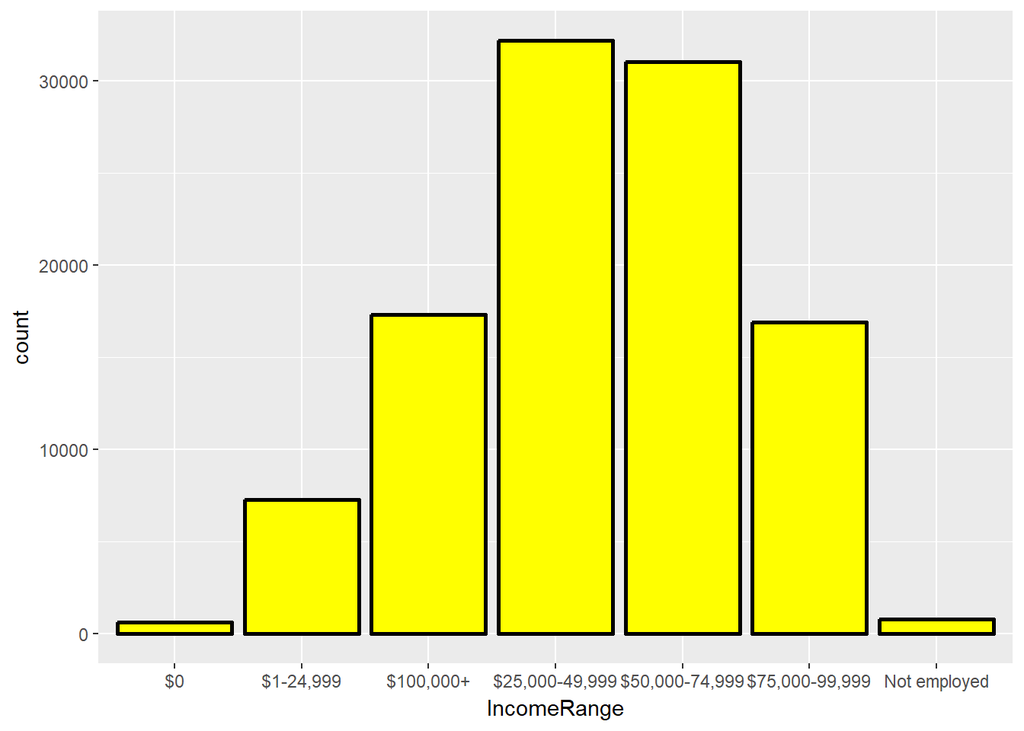

```
##             $0      $1-24,999      $100,000+ $25,000-49,999 $50,000-74,999
##            621           7274          17337          32192          31050
## $75,000-99,999  Not displayed   Not employed
##          16916           7741            806
```

> most of the Borrowers are in the $25,000-49,999 segment.

### the number of home owners.

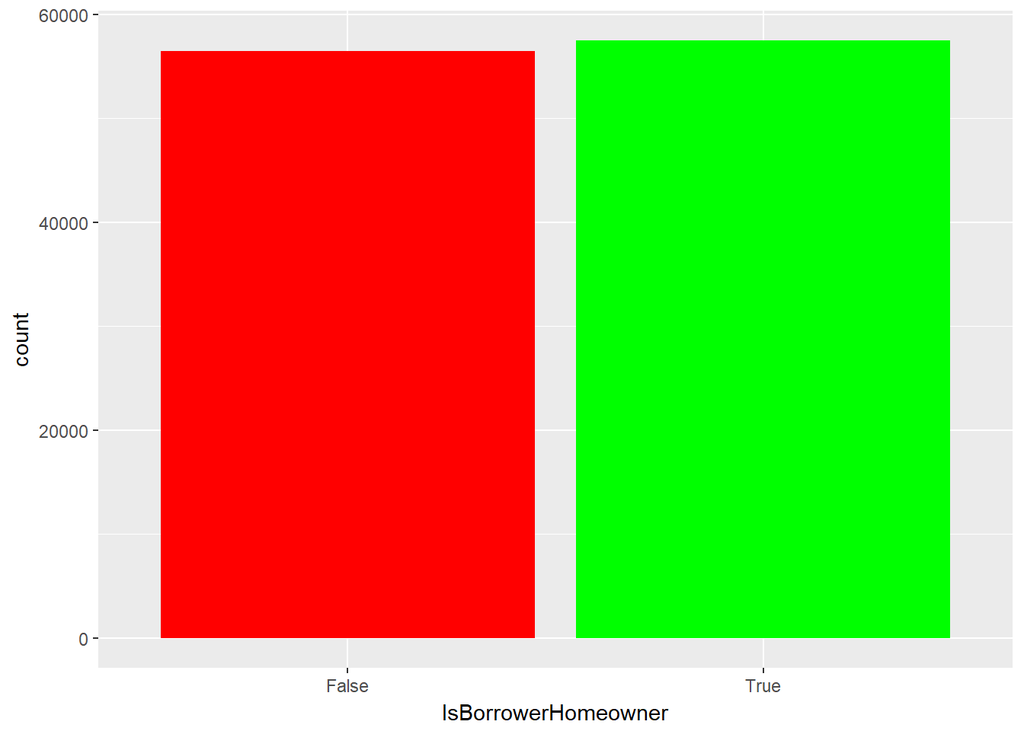

```
## False  True
## 56459 57478
```

> the number of those who own homes and those who don’t is very close.

### the Borrwoer rate interest

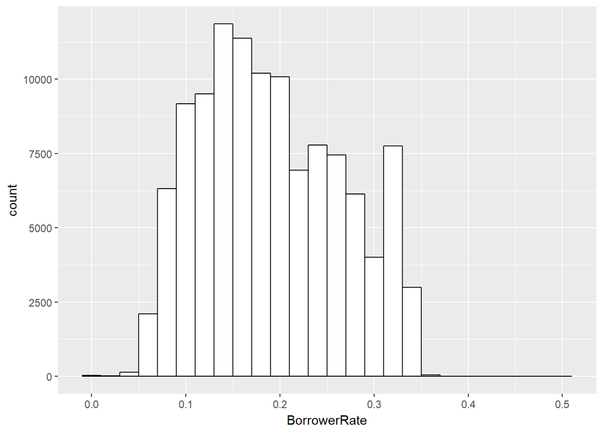

```
## [1] "the Mean is : "
```

```
## [1] 0.1927641
```

> this histogram displays the Borrower interest rate distribution of the Borrowers interest Rate, we can see that the average loan interest is 19.28 % and here’s the summary of the distribution including the five numbers summary.

```
##    Min. 1st Qu.  Median    Mean 3rd Qu.    Max.
##  0.0000  0.1340  0.1840  0.1928  0.2500  0.4975
```

### employment status

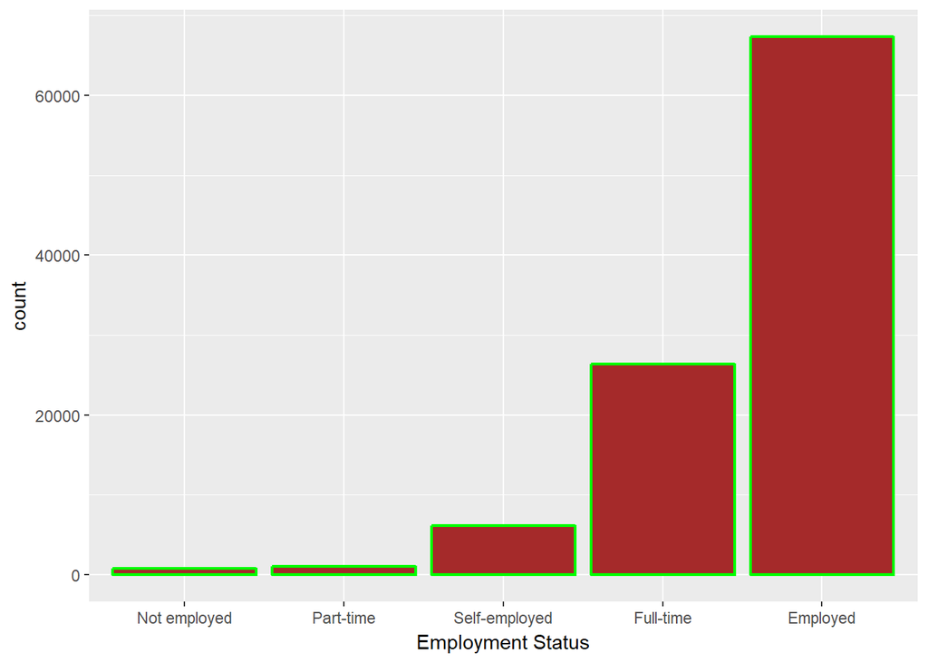

```
##  Not employed       Retired     Part-time Self-employed     Full-time
##           835             0          1088          6134         26355
##      Employed          NA's
##         67322         12203
```

> its obvious now that most of the Borrowers are employed.

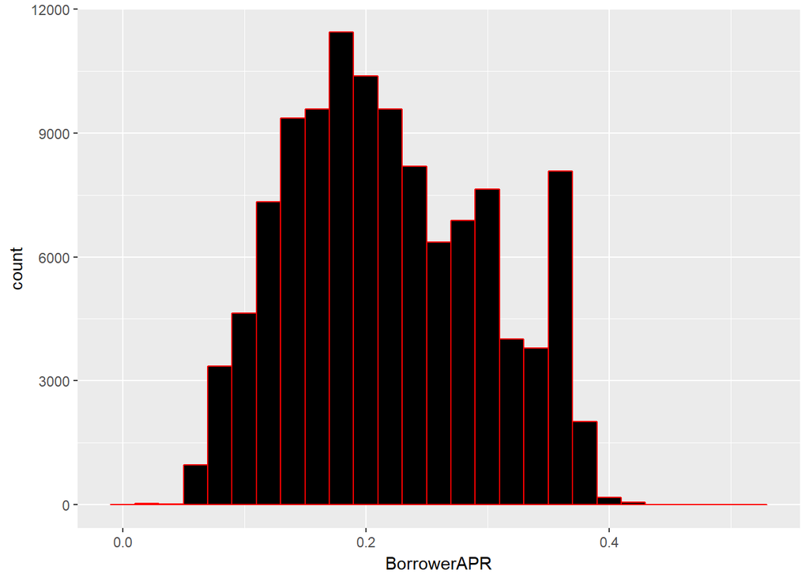

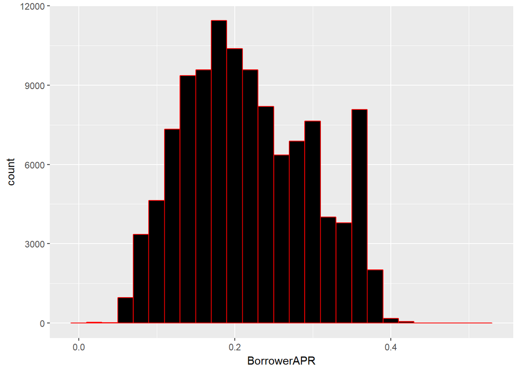

```
## [1] "The APR summary statistics is :"
```

```
##    Min. 1st Qu.  Median    Mean 3rd Qu.    Max.    NA's
## 0.00653 0.15629 0.20976 0.21883 0.28381 0.51229      25
```

> The loan APR ranges from less than 5 % up to about 51 %. Most borrowers seems to have a APR from 10 % upto 30 % with average equals to 21.9 %.

### Loan Status

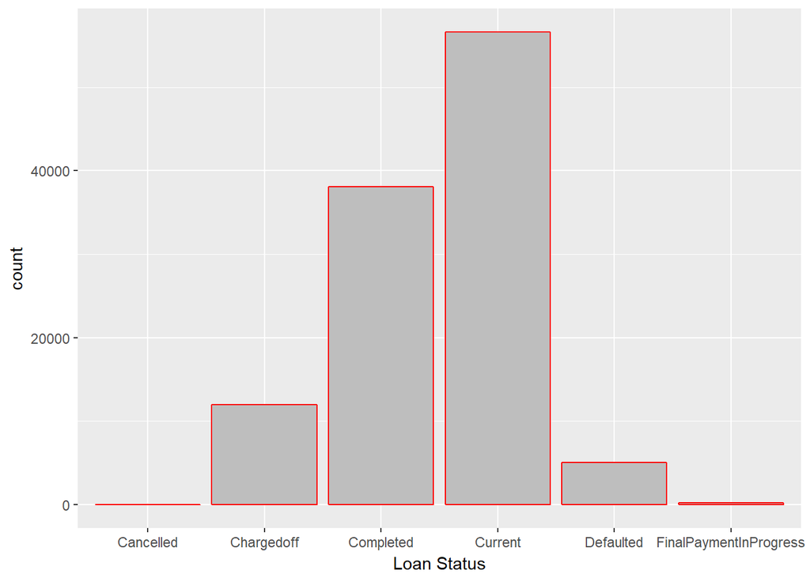

```
##               LoanStatus Percent
## 1              Cancelled    0.00
## 2             Chargedoff   10.72
## 3              Completed   34.03
## 4                Current   50.57
## 5              Defaulted    4.49
## 6 FinalPaymentInProgress    0.18
## 7               PastDue.    0.00
```

> most of the borrowers are still currently taking loans with a percentage of 50.57%, 34.03% has already completed, and 10.72% are charged off!

### Loan duration

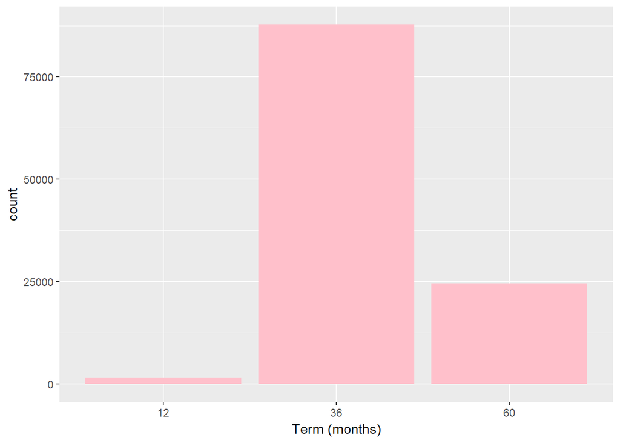

> 36 months is most common Term.

### ProsperRating Grade of the borrowers

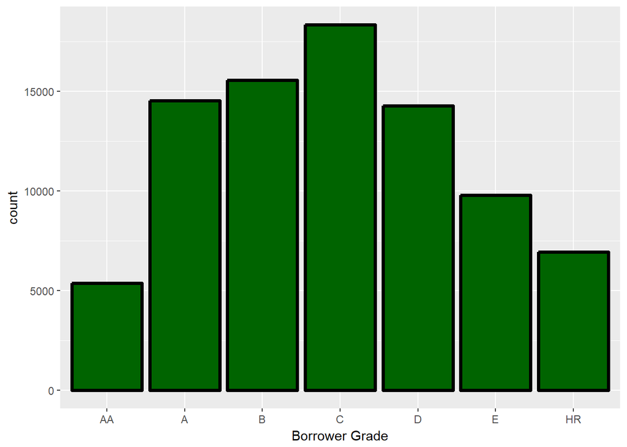

> the Grade is normally distributed with a mode equals to C.

### Lender Yield.

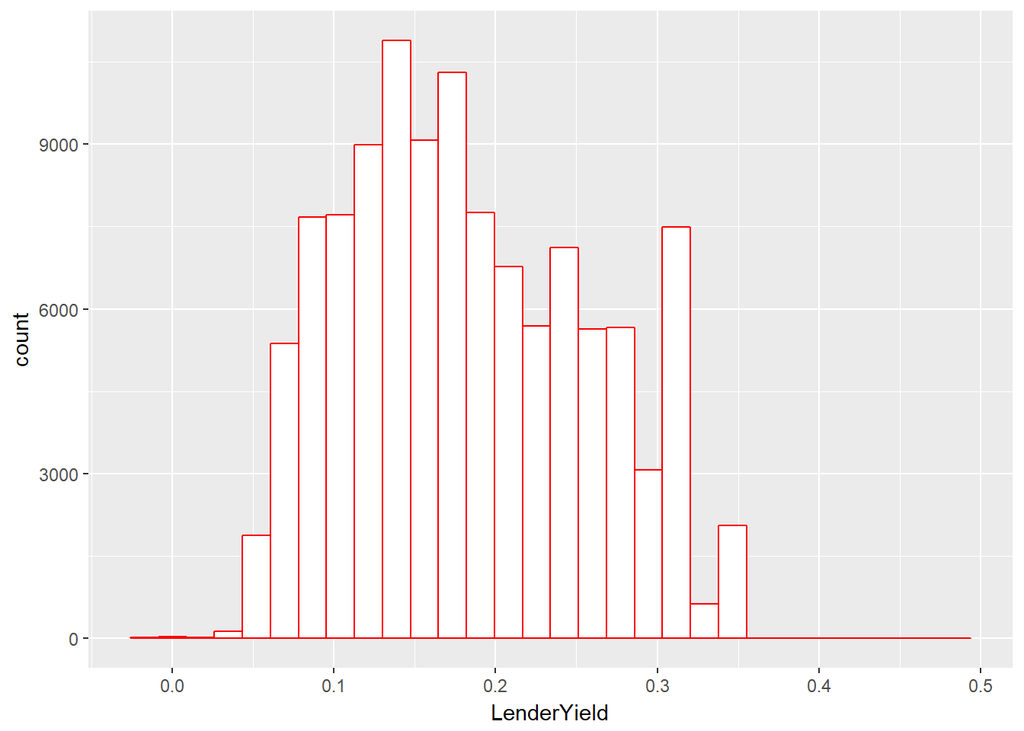

```
##    Min. 1st Qu.  Median    Mean 3rd Qu.    Max.
## -0.0100  0.1242  0.1730  0.1827  0.2400  0.4925
```

> Lender yield is equal to the interest rate on the loan less the servicing fee and it’s average equals 18.27% .

### Borrower APR.

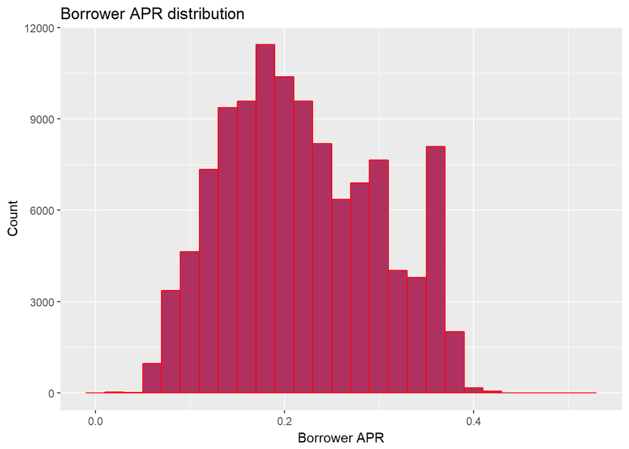

```
##    Min. 1st Qu.  Median    Mean 3rd Qu.    Max.    NA's
## 0.00653 0.15629 0.20976 0.21883 0.28381 0.51229      25
```

this plot shows the distribution of the Borrower APR Variable with an average equals to 21.88%.

# Bivariate Analysis

> some questions in my mind right now.. - is there a relationship between being a home owner and the loan status? probably the home owners complete their loans more quickly!?

### home owner by current loan status

```
## pld$IsBorrowerHomeowner: False
##              Cancelled             Chargedoff              Completed
##                      3                   6661                  19794
##                Current              Defaulted FinalPaymentInProgress
##                  26098                   2744                     95
##               PastDue.                   NA's
##                      0                   1064
## --------------------------------------------------------
## pld$IsBorrowerHomeowner: True
##              Cancelled             Chargedoff              Completed
##                      2                   5331                  18280
##                Current              Defaulted FinalPaymentInProgress
##                  30478                   2274                    110
##               PastDue.                   NA's
##                      0                   1003
```

[figure not shown]

a plot shows the relation between the Home owners and the Current status of loans.

### Estimated Effective Yield, EstimatedReturn and Estimated Loss

> - is there a relation betweem the Effective Yield and the Return or the Loss?

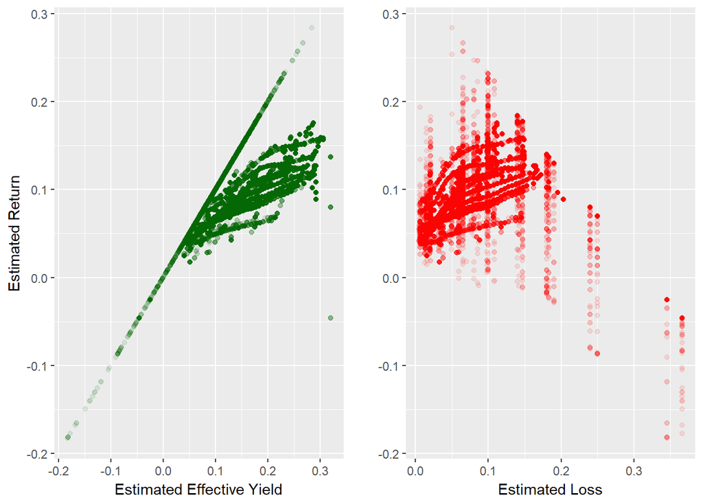

### Monthly payments with loan amount

> - probably the monhly payments has a relation with the loans amout, let’s make sure!?

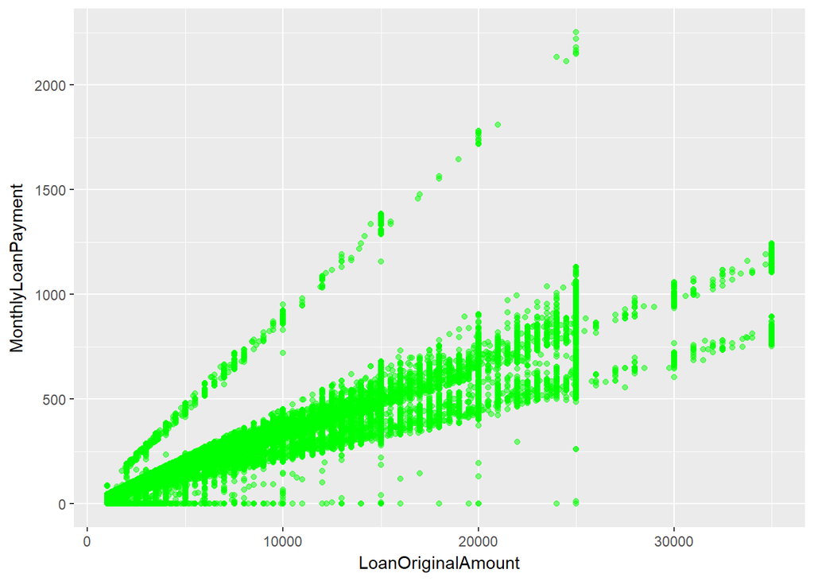

obviously the Higher Loans are correlated with the monthly Payments.

### Estimated loss and Prosper rating

> - bad ratings probably have a relation with the Estimated loss?

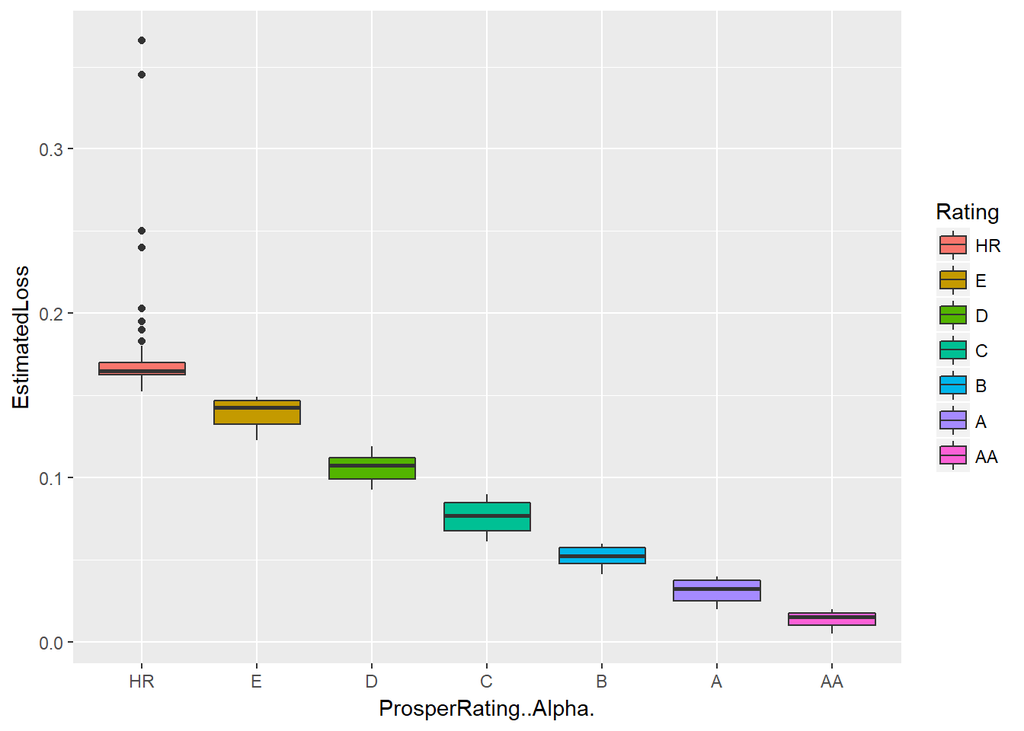

> Yep it’s a negative correlation, the bad ratings are associated with High Estimated Loss.

### Prosper rating and credit score

> is there’s a relation between the Prosper Ratin and the Credit score?

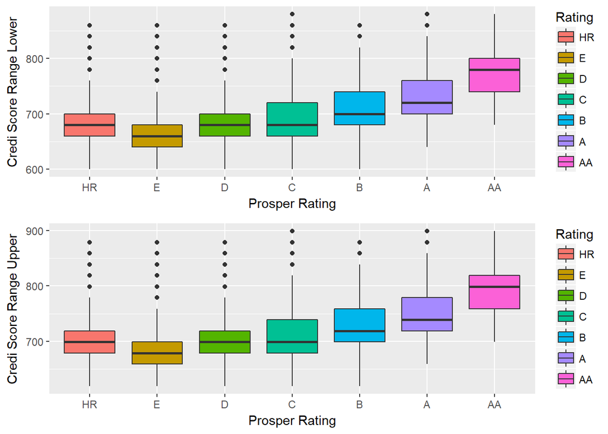

Credit scores have an impact on the proposer rating, as the credit score increases the Rating increases too which is too obvious.

### APR and Prosper rating

> - now let’s look at the APR, is there a relation between it and the Rating?

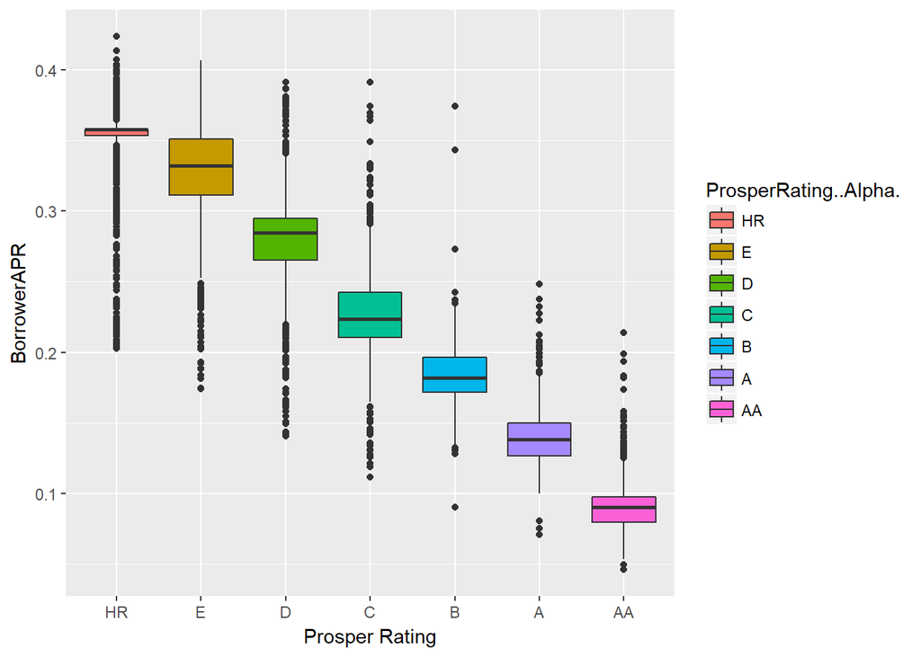

borrowers with good rating have lower APRs and those with bad ratings have high APRs.

### APR and interest rate

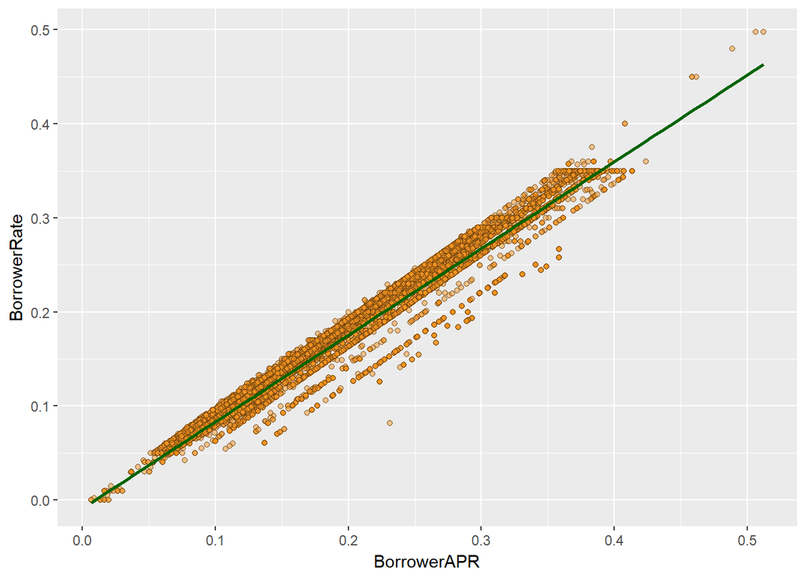

```
## [1] "The summary statistics of borrower APR is "
```

```
##    Min. 1st Qu.  Median    Mean 3rd Qu.    Max.    NA's
## 0.00653 0.15629 0.20976 0.21883 0.28381 0.51229      25
```

```
## [1] "The summary statistics of borrower rate is "
```

```
##    Min. 1st Qu.  Median    Mean 3rd Qu.    Max.
##  0.0000  0.1340  0.1840  0.1928  0.2500  0.4975
```

The borrower APR and rate are linearly related. The average APR and rate are ~ 22% and 19 % respectively. ### Loan Amount vs loan term

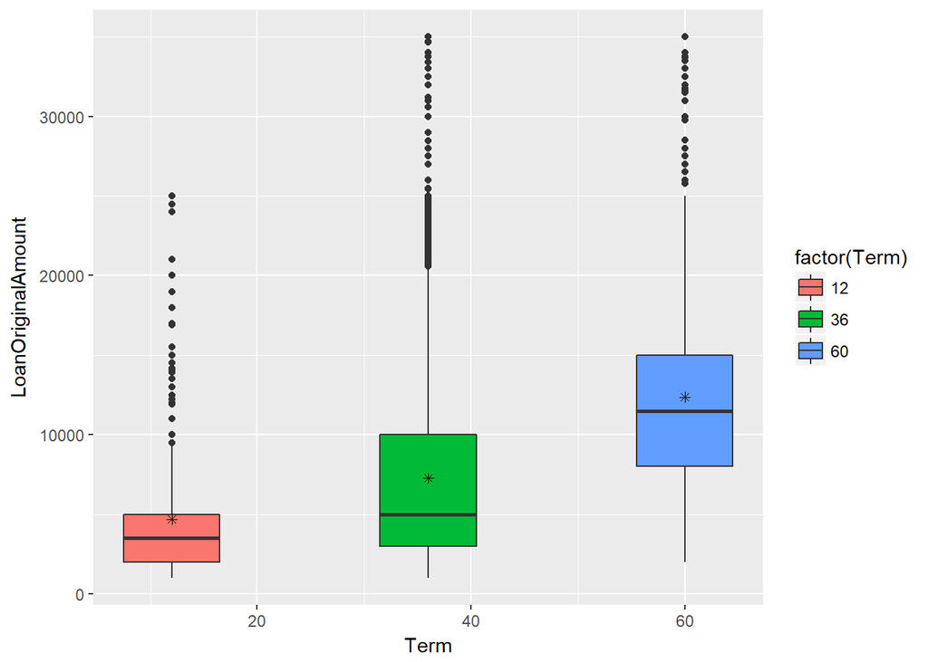

```
##    Min. 1st Qu.  Median    Mean 3rd Qu.    Max.
##    1000    4000    6500    8337   12000   35000
```

Bigger Terms are associated with the big Amounts of Loans. Using the summary stats, we can see the average loan amount is $8337 and the loan amount ranges between $1000 and $35000.

# MULTIVARIATE ANALYSIS

### Monthly payement by total loan and Loan Term

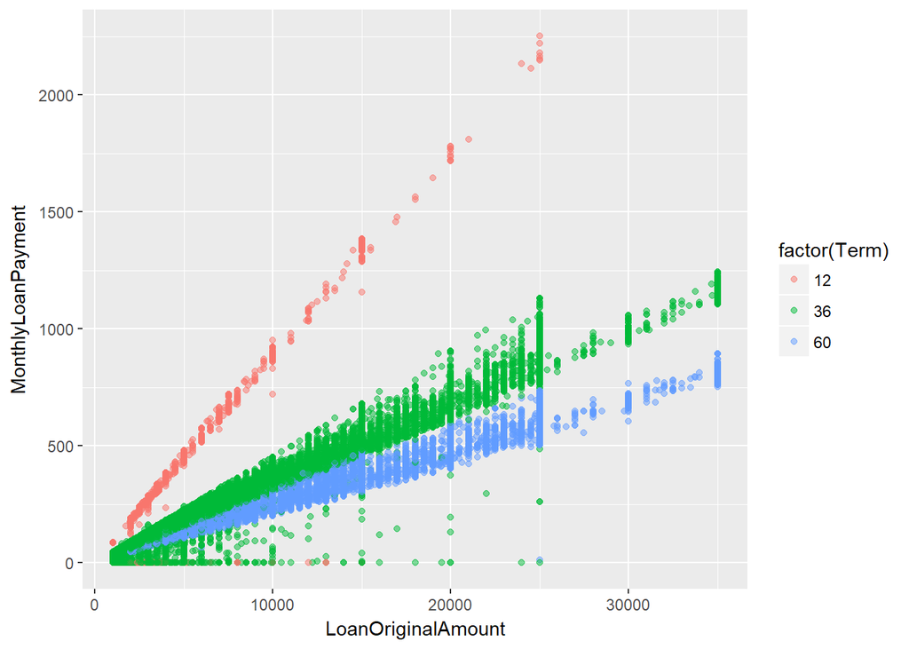

```
##    Min. 1st Qu.  Median    Mean 3rd Qu.    Max.
##     0.0   131.6   217.7   272.5   371.6  2251.5
```

we have seen that the monthly payment increases as the amount of loan gets bigger.For the same loan amount the monthly payment amount is higher for shorter terms. From the summary statistics we can see that the average monthly payment is almost $272.

### Borrower classification by loan range and loan term?

```
##        Loan_range Number_of_borrowers
## 1       (0,5e+03]               51824
## 2   (5e+03,1e+04]               31136
## 3 (1e+04,1.5e+04]               20033
## 4 (1.5e+04,2e+04]                5659
## 5 (2e+04,2.5e+04]                4605
## 6 (2.5e+04,3e+04]                 177
## 7 (3e+04,3.5e+04]                 503
```

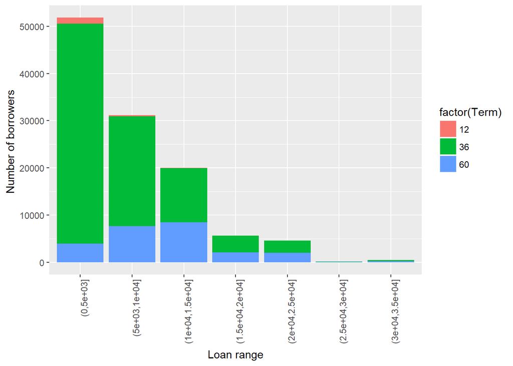

### Distribution of borrowers by loan range and employment status?

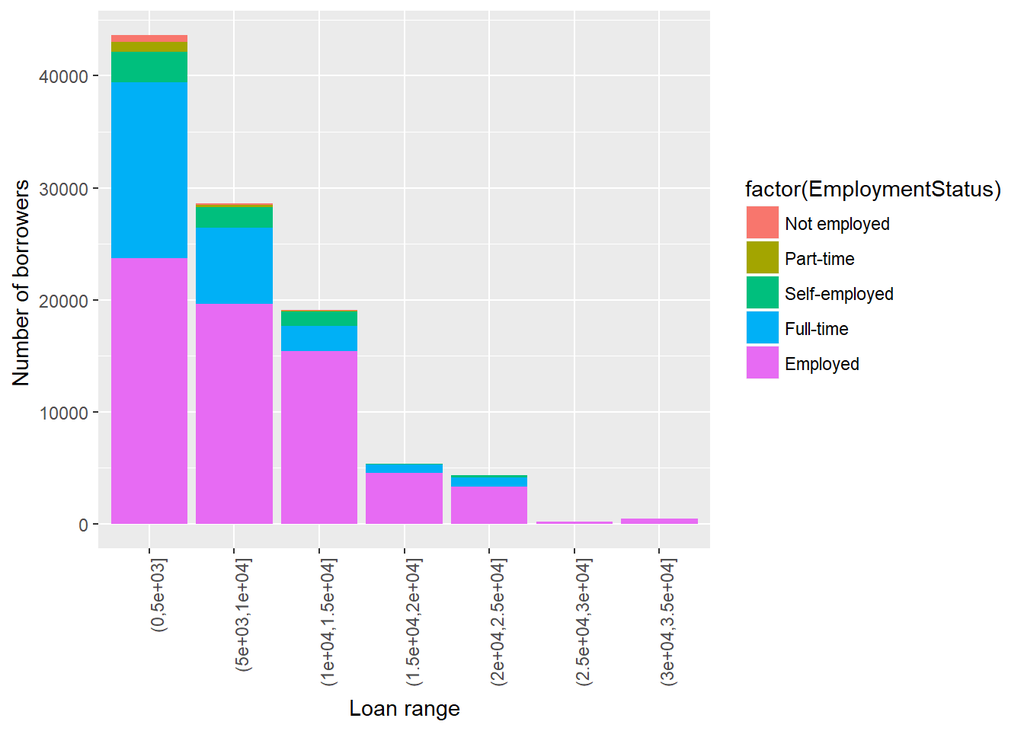

most prosper loan amounts are in the range of 0,5000 followed by 5000 - 10,000 and most borrowers are employed.

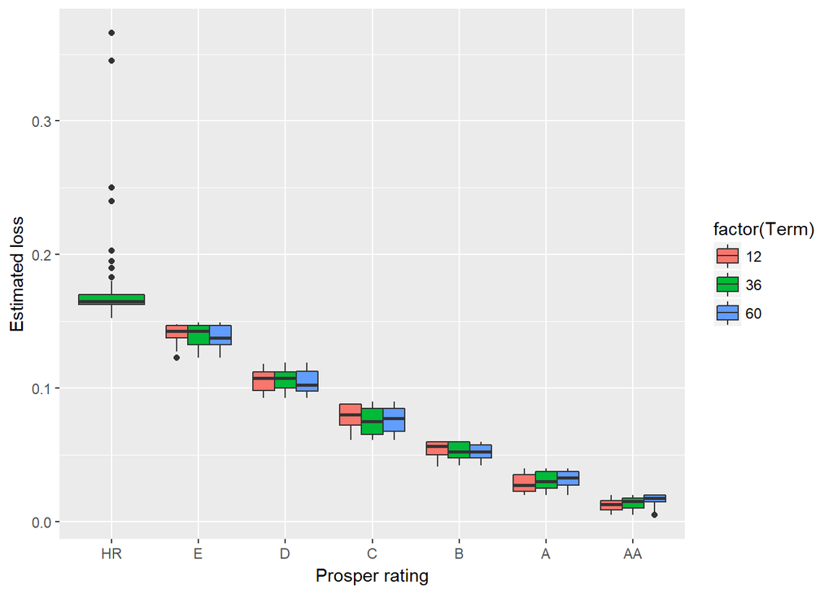

```
##    Min. 1st Qu.  Median    Mean 3rd Qu.    Max.    NA's
##   0.005   0.042   0.072   0.080   0.112   0.366   29084
```

The Estimated Loss Decreases as the Rating increases nd the Term is almost the same for all groups. ### APR with term and rating

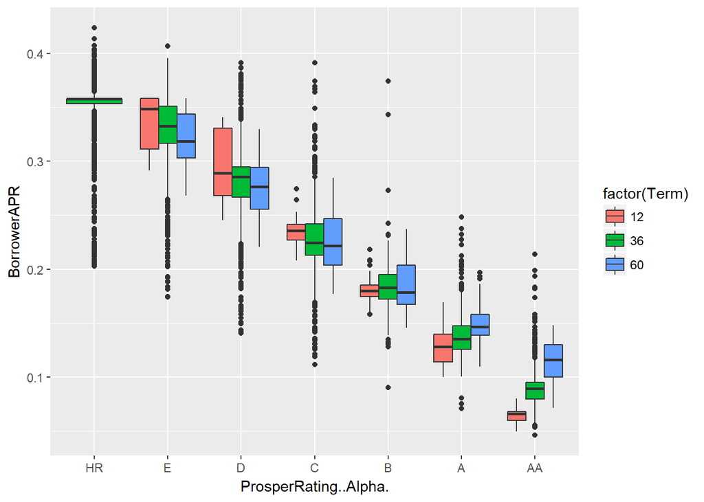

as the Rating Increases the APR decreases, and The 12 Months term members is kinda Decreasing until reaching a very small Ratio at the AA Rate.

### Correlation Table between different variables

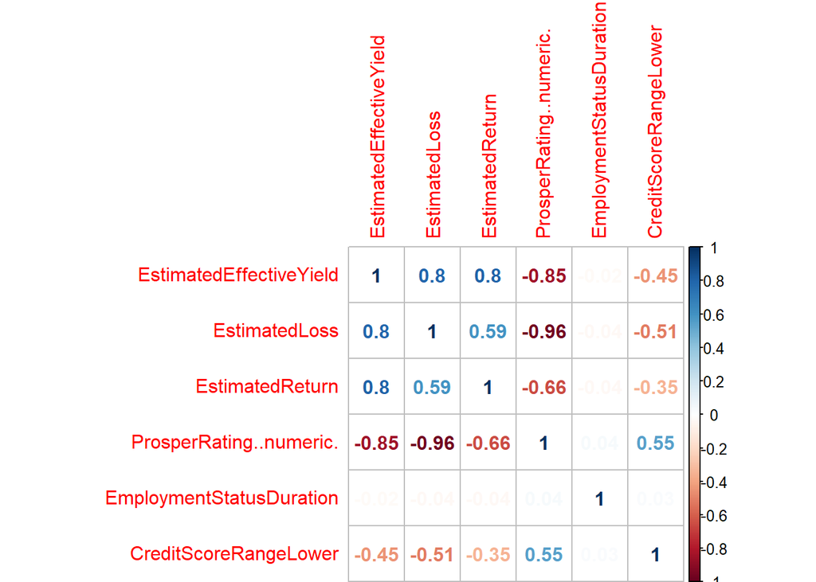

a correlation table of some variables.

# FINAL PLOTS

### Plot 1

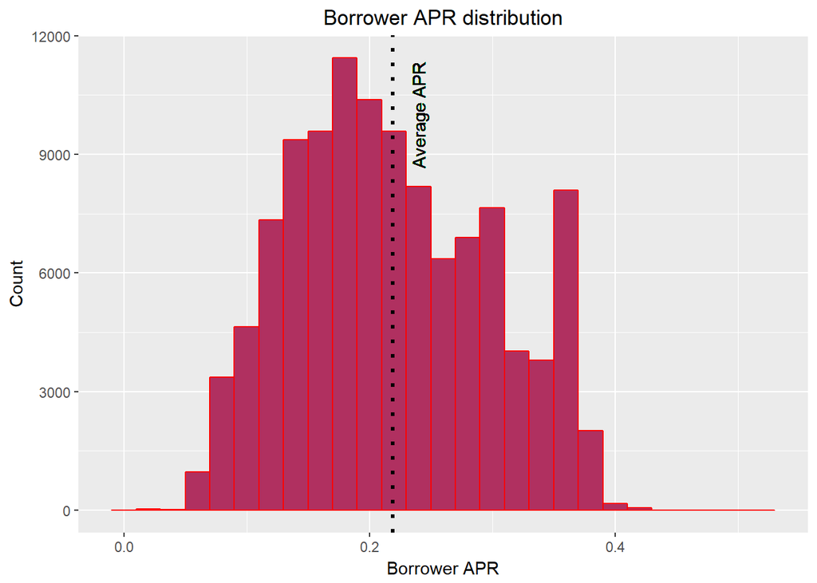

The loan APR ranges from less than 5 % up to about 51 %. However, there are only very few borrowers with such high and lower APR values. Most borrowers seems to have a APR from 10 % to 30 %. The median APR value is ~21 %.

### plot 2

```
## pld$IsBorrowerHomeowner: False
##              Cancelled             Chargedoff              Completed
##                      3                   6661                  19794
##                Current              Defaulted FinalPaymentInProgress
##                  26098                   2744                     95
##               PastDue.                   NA's
##                      0                   1064
## --------------------------------------------------------
## pld$IsBorrowerHomeowner: True
##              Cancelled             Chargedoff              Completed
##                      2                   5331                  18280
##                Current              Defaulted FinalPaymentInProgress
##                  30478                   2274                    110
##               PastDue.                   NA's
##                      0                   1003
```

[figure not shown]

### plot 3

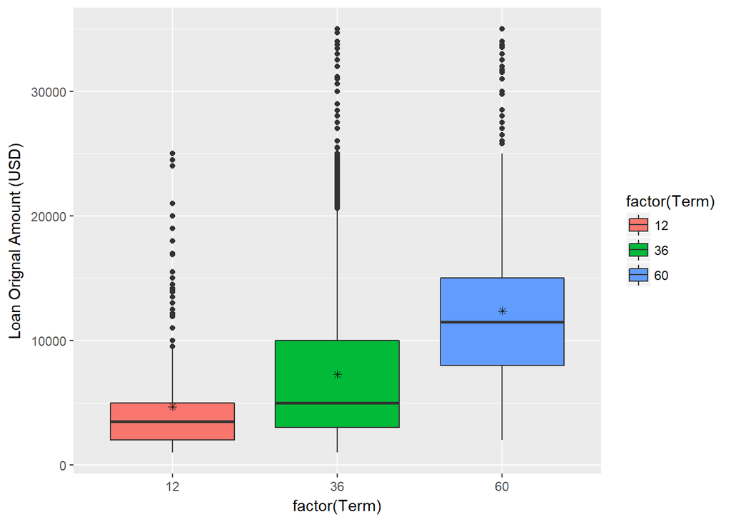

```
##    Min. 1st Qu.  Median    Mean 3rd Qu.    Max.
##    1000    4000    6500    8337   12000   35000
```

Bigger Terms are associated with the big Amounts of Loans. Using the summary stats, we can see the average loan amount is $8337 and the loan amount ranges between $1000 and $35000.

# REFLECTION

The Prosper loan data set has 113,937 rows and 81 features. I explored some of the 81 variables and tried to find interesting relationships among the  
variables. My focus of investigation was mostly on the profile of the borrowers such as income range, employment, credit score etc.. and the features of the loan such as APR, estimated loss, loan amount with Term etc..,. I used ggplot to check how these variable distributed and related. On the process of exploration, I found many missing values in the data and I handeled the problem using R data cleaning tools such as from the subset function.

From the exploration of the data, I found the APR varies from less than 1 % upto a little higher than 50 %. The APR is related to the credit score of the borrowers. It is foud that borrowers with high credit scores have good prosper rating and lower APR. It is also found that most borrowers have loans in the range from 1-5000 for aperiod of 36 months. Finally I plotted the correlation table of many variables and seen many interesting correlations.

# REFERENCES

https://docs.google.com/document/d/e/2PACX-1vRmVtjQrgEPfE3VoiOrdeZ7vLPO_p3KRdb_o-z6E_YJ65tDOiXkwsDpLFKI3lUxbD6UlYtQHXvwiZKx/pub?embedded=true https://s3.amazonaws.com/content.udacity-data.com/courses/ud651/ diamondsExample_2016-05.html http://stackoverflow.com/